# LMF Selection Index Dashboard - User Manual

CGIAR - ICARDA: version 0.1.0 (beta)

2026-07-05

## Overview

The Low-Methane Forages (LMF) Selection Index Dashboard is an R Shiny application that enables researchers to:

- Upload raw multi-trial accession data (CSV or Excel)
- Compute run-adjusted trait estimates using **BLUEs** (mixed models) or arithmetic means
- Classify accessions by methane intensity and digestibility categories
- Calculate weighted composite selection scores across four selection approaches simultaneously
- Visualize accession distribution with interactive scatter plots
- Export ranked results classified in all groups as a multi-sheet Excel workbook

[figure not shown]

LMF Selection Index Dashboard interface

## Running the Application

Before running the application, ensure that both R and RStudio are installed on your computer. No additional package installation or configuration is required. Simply open the app.R file in RStudio and click Run App. On the first run, the application will automatically check for any required R packages and install those that are missing. Once the application launches in your web browser, upload your dataset, map the required columns if prompted, configure the desired thresholds and weights, and click **Run Analysis** to calculate the selection index, populate each selection category (displayed as separate sub-tabs), rank entries within each category, and generate the associated visualizations, diagnostics, and downloadable results.

## Step-by-Step Workflow

### 1. Upload Data

Click **“Upload Data File”** and select a CSV or Excel file (max 50 MB). The file should contain one row per observation with columns for accession ID, trial/run ID, and numerical or categorical traits.

After upload, a preview of all rows appears in the **Data Preview** tab.

### 2. Map Columns

The **Column Mapping** section appears after upload. Assign the following roles:

| Field | Description | Required |
| --- | --- | --- |
| Accession ID Column | Unique sample genotype identifier | Yes |
| Trial/Run ID Column | Unique Experimental run identifier | Yes |
| CH4 Intensity Column | Methane intensity (ml CH4/g TDDM) | Yes |
| TDDM Column | Truly Digested Dry Matter (%) | Yes |
| CH4 8h Column | CH4% after 8h | No |
| CH4 24h Column | CH4% after 24h | No |
| Grouping Columns | Categorical variables for visualization only (e.g., Functional Group) | No |
| Additional Columns | Extra numeric columns for visualization only (e.g., Biomass) | No |

Column names are auto-detected by pattern matching where possible. Click **“Confirm Mapping”** to validate and lock in the mapping. The section collapses after confirmation. Click the ▶ header to re-expand if needed.

### 3. Run Analysis

Click **“Run Analysis”**. The pipeline executes:

1. **Aggregation:** Computes accession-level estimates (BLUEs by default, or arithmetic mean)
2. **Classification:** Assigns CH4 Intensity and TDDM categories based on configured thresholds
3. **Scoring:** Calculates Z-scores, composite scores, and competition rankings for all 4 approaches
4. **Diagnostics:** Generates CV%, variance components, and data quality metrics

### 4. Review Results

Switch between tabs in the main panel:

- **Data Preview:** Full uploaded dataset with pagination (10 rows per page)
- **Selection Results:** Four sub-tabs (Category 1a, 1b, 2, 3) showing ranked accessions
- **Scatter Plot:** TDDM vs CH4 Intensity with threshold lines, sector counts, and marginal density curves
- **Diagnostics:** Dataset summary, CV% table, variance components chart, LSD values, and control verification

### 5. Export Results

Click **“Download Excel”** to generate a multi-sheet workbook containing:

- One sheet per selection approach (ranked by Overall_Rank)
- Configuration sheet (all analysis settings)
- Diagnostics sheet (quality metrics)

## Configuration Settings

Expand the **▶ Configuration** section in the sidebar to adjust:

| Setting | Default | Description |
| --- | --- | --- |
| Aggregation Method | BLUEs | BLUEs (mixed model, run-adjusted) or Arithmetic Mean |
| CH4 Low Threshold | 35% | Decrease % cutoff for “Low” CH4 Intensity category (compare to the reference baseline average) |
| CH4 Medium Threshold | 20% | Decrease % cutoff for “Medium” CH4 Intensity category (compare to the reference baseline average) |
| TDDM High Cutoff | 60% | Threshold for “High” TDDM category |
| Reference Baseline | 10% | Top N% of accessions used to compute baseline |
| Reference Control ID | (select) | Check accession for benchmarking |
| Score Weights | varies | W1(CH4 Intensity) and W2(TDDM) per approach |

**Changes to any setting automatically trigger recalculation.**

## Selection Approaches

The dashboard computes four selection approaches simultaneously:

| Approach | CH4 Filter | TDDM Filter | Default Weights |
| --- | --- | --- | --- |
| Category 1a | Low | High | W1=2, W2=1 |
| Category 1b | Medium | High | W1=2, W2=1 |
| Category 2 | Not High | Not High | W1=1, W2=0 |
| Category 3 | High | High | W1=1, W2=2 |

**Composite Score** = W1 × Z_Score_CH4 + W2 × Z_Score_TDDM

Accessions are ranked within each approach by Composite Score (descending, highest = rank 1).

**Note:** Z Score used to standardized values for both traits to preserve true variation between individuals and maintain real differences when calculating the weighted composite score and the overall ranking based on it.

## Key Formulas

[output not shown]

**Note:** Z_Score_CH4 is negated because lower methane intensity is desirable. Accessions with lower CH4 receive higher (more positive) Z-scores.

## Aggregation Methods

### BLUEs (Default)

Best Linear Unbiased Estimates from a mixed model:

$$\text{trait} \sim \text{Accession
(fixed)} + (1 | \text{Trial})$$

BLUEs remove trial/run effects, providing cleaner rankings that reflect true biological differences rather than confounded run variation.

### Arithmetic Mean

Simple mean per accession across all observations. Appropriate when observations are collected under homogeneous conditions and no adjustment for run or batch effects is required.

## Diagnostics

The Diagnostics tab provides:

- **Dataset Summary:** Record counts, unique accessions/trials, observations per accession
- **Missing Values:** Count of NA/blank values per trait
- **CV% Table:** Technical-replicate coefficient of variation per trait (mean, median, SD, Q90)
- **Variance Components:** 100% stacked column chart showing % of variance from Accession, Trial, and Residual per trait
- **Average LSD:** Least Significant Difference for pairwise comparisons per trait
- **Reference Control Verification:** Checks whether the control accession is present in all trials

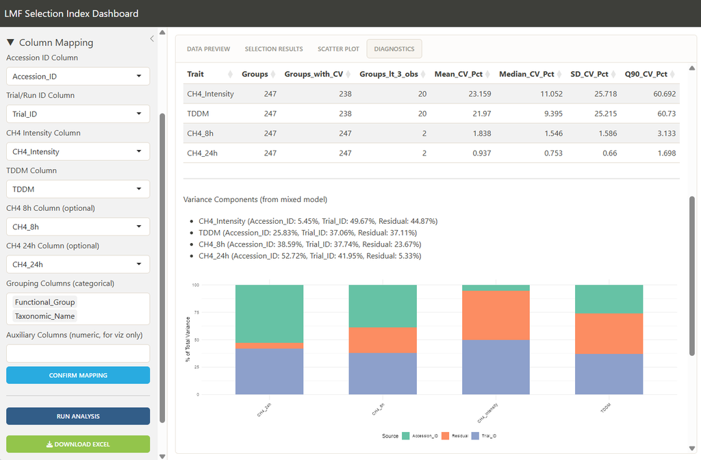

Diagnostics Tab showing CV% and Variance Component

## Tips

- Use **BLUEs** when data has multiple trials/runs, this removes run effects from rankings
- The scatter plot colour/size selectors default to “None”, select to encode additional variables, such as biomass, NDF, or functional group
- Click **“Download Plot”** in the Scatter Plot tab to save a 300 DPI PNG
- Run the app in browser mode for best rendering: `runApp(launch.browser = TRUE)`

## Troubleshooting

| Issue | Solution |
| --- | --- |
| All accessions in one category | Verify CH4 Intensity and TDDM columns are correctly mapped |
| BLUEs computation fails | Ensure data has multiple trials per accession (≥2 runs) |
| Plot not rendering | Use browser mode, not RStudio viewer pane |
| Download button disabled | Run the analysis first |
| “Boundary (singular) fit” warning | Normal for traits with low trial variance, results still valid |

*Developed for the CGIAR Low-Methane Forages (LMF) Project - ICARDA*